# Bike Sharing Demand

## Introduction

We have to predict the total count of bikes rented during each hour covered by the test set, using only information available prior to the rental period.

```r
require(plyr)
detach(package:plyr)
library(dplyr)
library(tidyr)
library(ggplot2)
library(stringr)
library(caret)
library(randomForest)
library(lubridate)
library(scales)
library(ggcorrplot)
library(parallel)
library(doParallel)
```

```r
train.data <- tbl_df(read.csv('./Input/train.csv', stringsAsFactors = F))
test.data <- tbl_df(read.csv('./Input/test.csv', stringsAsFactors = F))
```

## Data Pre-processing, Cleaning & Feature Extraction

Replacing season codes with corresponding values.

```r
season.list <- c('spring', 'summer', 'fall', 'winter')
replace_season <- function(df){
    df[['season']] <- plyr::mapvalues(df[['season']],
                                  from = c(1, 2, 3, 4),
                                  to = season.list)
    return(df)
}
train.data <- replace_season(train.data)
```

Creating Weather matrix as follows:  
weather 1: clear_partly_cloudy weather 2: mist_cloudy weather 3: light_snow_rain_thunderstorm weather 4: heavy_snow_rain_ice_fog_thunderstorm

```r
weather.list <- c('clear_partly_cloudy', 'mist_cloudy',
                  'light_snow_rain_thunderstorm',
                  'heavy_snow_rain_ice_fog_thunderstorm')
replace_weather <- function(df){
    df[['weather']] <- plyr::mapvalues(df[['weather']],
                                  from = c(1, 2, 3, 4),
                                  to = weather.list)

    return(df)
}
train.data <- replace_weather(train.data)
```

Splitting datetime into year, month, day_num, day_name, hour

```r
train.data <- train.data %>%
    mutate(date.year = 0, date.month = '', month.day = 0,
           week.day = '', day.hour = 0)
split_date <- function(df){
    df[['date.year']] = year(df[['datetime']])
    df[['date.month']] = month(df[['datetime']], label = T)
    df[['month.day']] = day(df[['datetime']])
    df[['week.day']] = wday(df[['datetime']], label = T)
    df[['day.hour']] = hour(df[['datetime']])

    return(df)
}
train.data <- split_date(train.data)
```

Adding new column, temp.div <- temp / atemp

```r
train.data <- train.data %>%
    mutate(temp.div = temp / atemp)
```

Adding new column, day.type – working day, holiday or weekend

```r
train.data <- train.data %>%
    mutate(day.type = NA)
day_type <- function(df){
    df[['day.type']] <- ifelse(df[['holiday']] == 1, 'Holiday',
                               ifelse(df[['workingday']] == 1, 'Workingday',
                                      'Weekend'))
    return(df)
}
train.data <- day_type(train.data) %>% select(-holiday, -workingday)
```

Converting into Tidy Data

```r
tidy.train.data <- train.data %>%
    group_by(datetime) %>%
    gather(key = user.type, value = user.count,
           casual:registered) %>%
    select(-count) %>% ungroup()
```

Converting columns into factors

```r
tidy.train.data[c(2:3, 8:12, 14:15)] <-
    lapply(tidy.train.data[c(2:3, 8:12, 14:15)], factor)
```

Now lets check the data again

```r
summary(tidy.train.data)
```

```
   datetime            season                                     weather
 Length:21772       fall  :5466   clear_partly_cloudy                 :14384
 Class :character   spring:5372   heavy_snow_rain_ice_fog_thunderstorm:    2
 Mode  :character   summer:5466   light_snow_rain_thunderstorm        : 1718
                    winter:5468   mist_cloudy                         : 5668



      temp           atemp          humidity        windspeed      date.year
 Min.   : 0.82   Min.   : 0.76   Min.   :  0.00   Min.   : 0.000   2011:10844
 1st Qu.:13.94   1st Qu.:16.66   1st Qu.: 47.00   1st Qu.: 7.002   2012:10928
 Median :20.50   Median :24.24   Median : 62.00   Median :12.998
 Mean   :20.23   Mean   :23.66   Mean   : 61.89   Mean   :12.799
 3rd Qu.:26.24   3rd Qu.:31.06   3rd Qu.: 77.00   3rd Qu.:16.998
 Max.   :41.00   Max.   :45.45   Max.   :100.00   Max.   :56.997

   date.month      month.day      week.day       day.hour        temp.div
 May    : 1824   1      : 1150   Sun  :3158   12     :  912   Min.   :0.2706
 Jun    : 1824   5      : 1150   Mon  :3102   13     :  912   1st Qu.:0.8119
 Jul    : 1824   9      : 1150   Tues :3078   14     :  912   Median :0.8528
 Aug    : 1824   17     : 1150   Wed  :3102   15     :  912   Mean   :0.8496
 Dec    : 1824   4      : 1148   Thurs:3106   16     :  912   3rd Qu.:0.8762
 Oct    : 1822   7      : 1148   Fri  :3058   17     :  912   Max.   :2.9092
 (Other):10830   (Other):14876   Sat  :3168   (Other):16300
       day.type          user.type       user.count
 Holiday   :  622   casual    :10886   Min.   :  0.00
 Weekend   : 6326   registered:10886   1st Qu.:  9.00
 Workingday:14824                      Median : 44.00
                                       Mean   : 95.79
                                       3rd Qu.:137.00
                                       Max.   :886.00
```

## Data Exploration

First lets check the proportion of casual to registered users

```r
tidy.train.data %>% mutate(total.count = sum(user.count)) %>%
    group_by(user.type) %>%
    mutate(count = sum(user.count) , prop = count / total.count) %>%
    select(user.type, count, prop) %>%
    distinct()
```

| user.type | count | prop |
| --- | --- | --- |
| casual | 392135 | 0.1880314 |
| registered | 1693341 | 0.8119686 |

### No. of Users by Season

Lets check the effect of seasons on the users

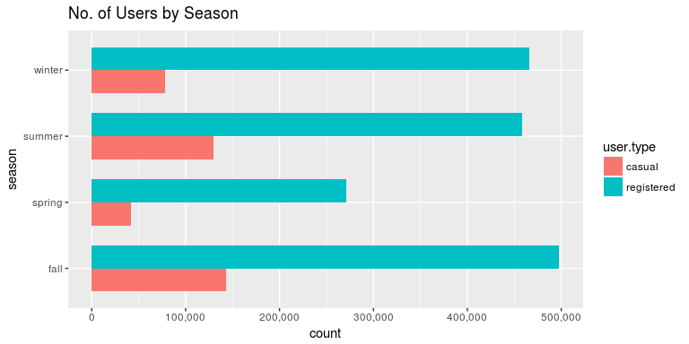

```r
plot.users.by.season <- tidy.train.data %>%
    select(season, user.type, user.count) %>%
    group_by(season, user.type) %>%
    mutate(count = sum(user.count)) %>%
    distinct(season, user.type, count) %>%
    ggplot(mapping = aes(season, count, fill = user.type)) +
    geom_bar(stat = 'identity', position = 'dodge', width = 0.7) +
    scale_y_continuous(labels = comma) +
    coord_flip() +
    ggtitle('No. of Users by Season')
plot.users.by.season
```

It seems less people ride bicycles during Spring season than other seasons.

In winter and spring the proportion of casual users decreases in comparision to registered users.

### No. of Users by Weather

Lets check the user count by weather

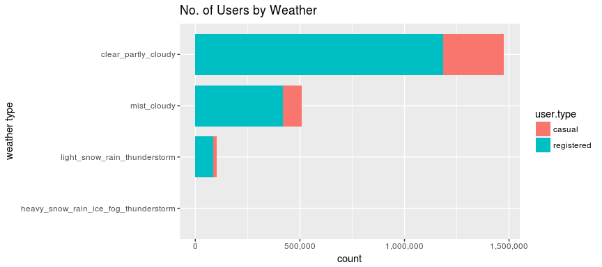

```r
plot.users.by.weather <- tidy.train.data %>%
    select(weather, user.type, user.count) %>%
    group_by(weather, user.type) %>%
    mutate(count = sum(user.count)) %>%
    distinct(weather, user.type, count) %>%
    ggplot(mapping = aes(reorder(weather, count), count,
                         fill = user.type)) +
    geom_bar(stat = 'identity', width = 0.8) +
    scale_y_continuous(labels = comma) +
    coord_flip() +
    xlab('weather type') +
    ggtitle('No. of Users by Weather')
plot.users.by.weather
```

Most people ride during good weather (Clear, Partly Cloudy). Only the most dedicated ride in bad weather (Thunderstorm, Light snow or Rain).

### No. of Users over Days of Week

Lets check user count over days of week

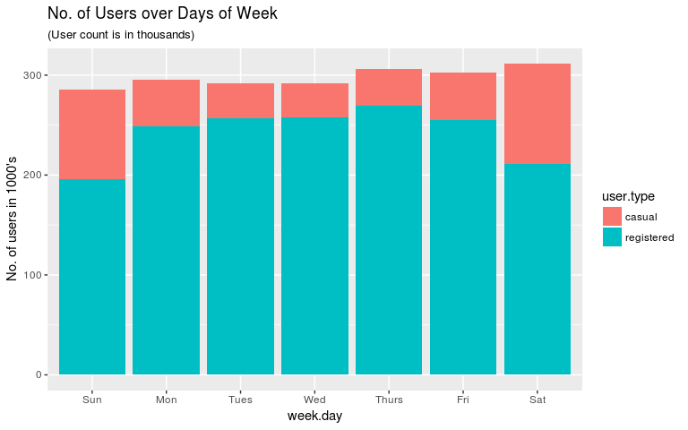

```r
plot.users.over.days.of.week <-tidy.train.data %>%
    select(week.day, user.type, user.count) %>%
    group_by(week.day, user.type) %>%
    mutate(count = sum(user.count)) %>%
    distinct(week.day, user.type, count) %>%
    ggplot(mapping = aes(x = week.day, y = count/1000,
                         fill = user.type)) +
    geom_bar(stat = 'identity') +
    ylab('No. of users in 1000\'s') +
    ggtitle(label = 'No. of Users over Days of Week',
            subtitle = '(User count is in thousands)')
plot.users.over.days.of.week
```

While the overall count of users remains pretty much the same over the week, more casual users ride bicycles on weekends; and the registered users prefer to ride during the weekdays.

### No. of Users based on Hour of Day

Lets check what time of the day most users ride.

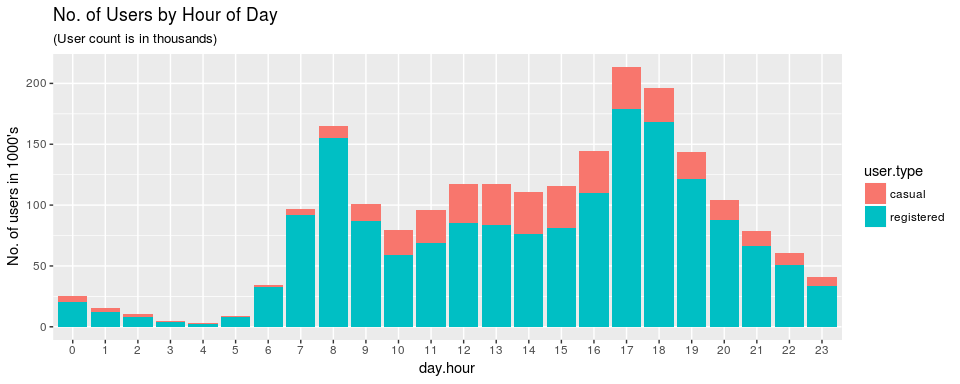

```r
plot.users.by.hour.of.day <- tidy.train.data %>%
    select(day.hour, user.type, user.count) %>%
    group_by(day.hour, user.type) %>%
    mutate(count = sum(user.count)) %>%
    distinct(day.hour, user.type, count) %>%
    ggplot(mapping = aes(x = day.hour, y = count/1000,
                         fill = user.type)) +
    geom_bar(stat = 'identity') +
    ylab('No. of users in 1000\'s') +
    ggtitle(label = 'No. of Users by Hour of Day',
            subtitle = '(User count is in thousands)')
plot.users.by.hour.of.day
```

As expected, most users ride between 6 AM to 11 PM. The bicycle use peaks at 8 AM and between 4 PM to 7 PM.

### No. of Users based on Hour of Day by Season

Lets see if the usage pattern changes in different seasons.

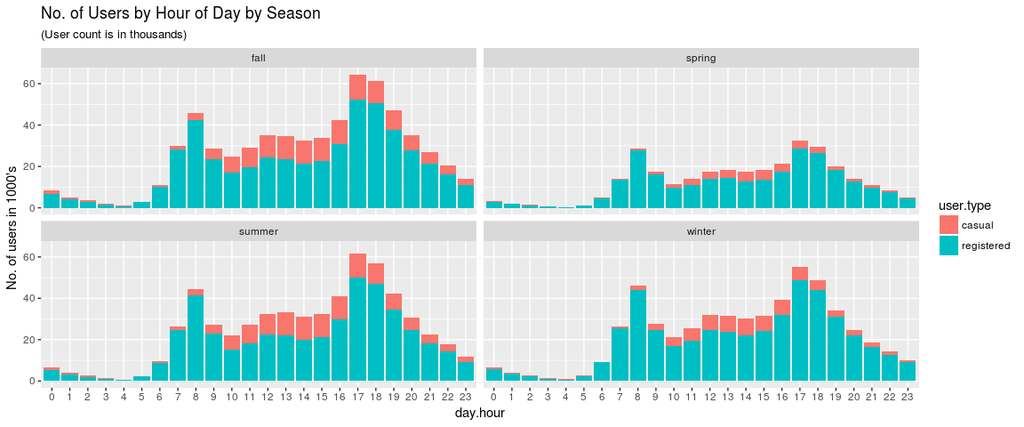

```r
plot.users.by.hour.of.day.by.season <- tidy.train.data %>%
    select(season, day.hour, user.type, user.count) %>%
    group_by(season, day.hour, user.type) %>%
    mutate(count = sum(user.count)) %>%
    distinct(season, day.hour, user.type, count) %>%
    ggplot(mapping = aes(x = day.hour, y = count/1000,
                         fill = user.type)) +
    geom_bar(stat = 'identity') +
    facet_wrap(~ season) +
    ylab('No. of users in 1000\'s') +
    ggtitle(label = 'No. of Users by Hour of Day by Season',
            subtitle = '(User count is in thousands)')
plot.users.by.hour.of.day.by.season
```

Nothing new here. We already knew that there are less users overall during Spring. The usage pattern by hour of day is same in all 4 seasons.

### Correlaton between Temperature, Humidity, Windspeed and User Count

Lets see the correlation between Temperature, Humidity, Windspeed and User Count.

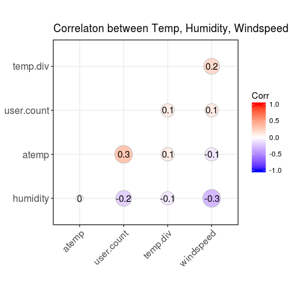

```r
plot.corr.temp.hum.wind.user <- tidy.train.data %>%
    select(atemp, temp.div, humidity, windspeed, user.count) %>%
    distinct() %>% cor() %>% round(digits = 1) %>%
    ggcorrplot(method = 'circle',
               type = 'lower', hc.order = T, lab = T, lab_size = 4,
               ggtheme = theme_bw,
               title = 'Correlaton between Temp, Humidity, Windspeed & UserCount')
plot.corr.temp.hum.wind.user
```

User Count seems to have positive correlation to Temperature and negative to humidity.

## Model Training, Prediction & Evaluation

We will use Linear Model, Decision Tree(RPart) & Random Forest to train our models.

First we will Configure parallel processing

```r
ncluster <- makeCluster(detectCores() - 1)
registerDoParallel(ncluster)
```

Splitting training and testing datasets

```r
set.seed(777)
sample.train.data <- sample_n(tidy.train.data, size = 2000)

inTraining <- createDataPartition(y = sample.train.data$user.count,
                                  p = 0.75, list = F)
training <- sample.train.data[inTraining, ]
testing <- sample.train.data[-inTraining, ]
```

```r
# set.seed(777)
#
# inTraining <- createDataPartition(y = tidy.train.data$user.count,
#                                   p = 0.75, list = F)
# training <- tidy.train.data[inTraining, ]
# testing <- tidy.train.data[-inTraining, ]
```

Setting train control and grid parameters

```r
tr.ctrl <- trainControl(method = 'repeatedcv', number = 5, repeats = 5,
                        verboseIter = T, allowParallel = T)
grid.rf <- expand.grid(.mtry = c(2, 4, 7, 14))
```

Training models

```r
set.seed(777)
fit.lm <- train(x = training[2:15], y = training$user.count, method = 'lm',
                metric = 'RMSE', trControl = tr.ctrl)
```

```r
set.seed(777)
fit.rpart <- train(x = training[2:15], y = training$user.count, method = 'rpart',
                metric = 'RMSE', trControl = tr.ctrl)
```

```r
set.seed(777)
fit.rf <- train(x = training[2:15], y = training$user.count, method = 'rf',
                metric = 'RMSE', trControl = tr.ctrl, tuneGrid = grid.rf)
```

Evaluating the models

```r
resamps <- resamples(list(LM = fit.lm,
                          RPART = fit.rpart,
                          RF = fit.rf))
summary(resamps)
```

```
Call:
summary.resamples(object = resamps)

Models: LM, RPART, RF
Number of resamples: 25

RMSE
          Min.  1st Qu.   Median     Mean  3rd Qu.     Max. NA's
LM    70.09006 74.59175 77.62448 78.00751 81.13155 90.97583    0
RPART 77.65831 82.08138 83.73737 84.28776 87.03123 98.99478    0
RF    44.63500 47.98801 49.70454 50.59659 51.75424 60.41011    0

Rsquared
           Min.   1st Qu.    Median      Mean   3rd Qu.      Max. NA's
LM    0.4937304 0.5418917 0.5643471 0.5567672 0.5742914 0.5957714    0
RPART 0.2711015 0.4443705 0.4901671 0.4809010 0.5150597 0.6061234    0
RF    0.7523360 0.8060796 0.8232946 0.8208759 0.8386853 0.8755465    0
```

Variable Importance

```r
varImp(object = fit.lm , scale = T)
varImp(object = fit.rpart)
varImp(object = fit.rf)
```

[output not shown]

De-registering parallel processing cluster

```r
stopCluster(ncluster)
registerDoSEQ()
```

Lets run the model on our testing split.

```r
predict.rf <- predict(fit.rf, newdata = testing)
```

Lets evaluate our model

```r
RMSE(pred = predict.rf, obs = testing$count)
```

[output not shown]